# Host-parasite coevolution; origin and maintenance of sex

## Antagonistic coevolution

The costs of parasitism lead to **antagonistic coevolution** between hosts and parasites.

Hosts can evolve **resistance** (typically by closing the compatibility filter) or **tolerance** (focusing on resistance this week).

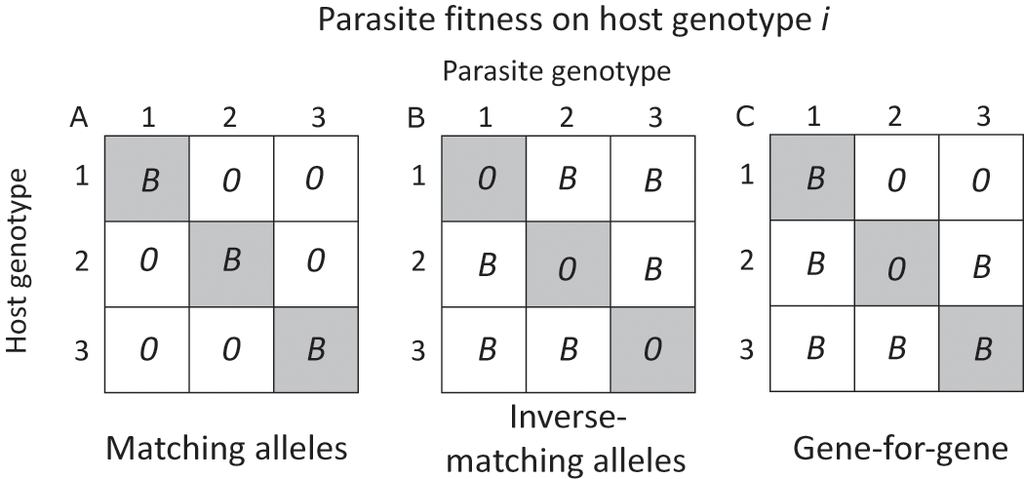

(Gibson and Lively (2019); see also Dybdahl and Storfer (2003))

- **matching alleles**: e.g. host has a **self-nonself recognition system** (typical in inverts); parasite succeeds if it matches (i.e. looks like host). Favors local adaptation, cycling/variation, dilution effects.
- **inverse matching alleles**: host matches many parasite signals (e.g. vertebrate antibody/antigen matching); parasite succeeds if it **does not** match any of the host antibodies. Doesn’t favour rare host genotypes, anti-dilution effects.
- **gene-for-gene**: like inverse matching, but there is a “universal infector” that doesn’t match anything (i.e. infects everything) (Plants: R genes, Avr genes). [Wikipedia](https://en.wikipedia.org/wiki/Gene-for-gene_relationship):

> Because there would be no evolutionary advantage to a pathogen keeping a protein that only serves to have it recognised by the plant, it is believed that the products of Avr genes play an important role in virulence [= ability to infect] in genetically susceptible hosts

Stahl et al. (1999): **Arms races** in a disease-resistance locus of *Arabidopsis*

- **trench warfare**/arms race (unidirectional)
  - resistance builds up until benefits balanced by costs
  - resistance alleles *polymorphic*
  - short-term *stabilizing* selection
  - long-term frequency cycling

## Antagonistic coevolution and sex

**Sex and variations**: we consider **dioecy** or **gonochory** (individuals are either male or female), but there are many variations: individuals may be **sequential** or **simultaneous** hermaphrodites. They may **self-fertilize** or **outcross** to different degrees.

**Costs of sex**: mating failure (vs. *reproductive assurance*), cost of males, **cost of meiosis** (when only half your genes make it into your offspring, you essentially pay a 50% fitness cost). Cost of outbreeding (breaking up co-adapted gene complexes: Goldberg et al. (2005)).

Simplest if we just think of cost of meiosis and advantages of recombination, although other costs and benefits do apply.

**Advantages of sex** (not necessarily parasite-related)

- **Muller’s ratchet** (fixation of deleterious alleles within lineages) [small (10–100 individuals) populations only];
- “Kondrashov’s hatchet” (Kondrashov 1993) (an analogue that works in large populations, with epistasis); natural selection is *more* effective at purging deleterious mutations. Also see Keightley and Otto (2006) on mutation purging.
- Hard (frequency-independent) habitat selection: allows sexual populations to inhabit transient niches that may not be available to asexuals; increases probability of making it through bad years
- Soft (frequency-dependent) or “tangled bank” habitat selection: allows sexual populations to avoid competition better, since they can use a wider variety of niches

**Requirements for RQ dynamics**

- heritable variation in host resistance to parasites
- heritable variation in parasite infectivity
- specificity

## Snails and trematodes

Primary theories for the variation in frequency of sexual snails among and within lakes:

- **Resistance tradeoffs:** genetic tradeoff between competitive ability and resistance to parasites
- **Reproductive assurance:** asexuals ensure reproduction and avoid costs of mating (assuming sexuals have some other advantage)
- **Lottery:** sexuals survive in a wider range of (micro)habitats
- **Tangled bank:** rare offspring of sexuals experience less competition
- **Red Queen:** sexuals (or uncommon clones) resist parasites better

|  | findings | resistance tradeoffs negative corr between comp ability of asex & parasite load | resistance tradeoffs negative corr between freq of asex & parasite load | reproductive assurance asex↑at low pop density | reproductive assurance asex ↑in unstable env | lottery asex fail alone in habitats OK for sex | lottery asex ↑in temporally variable env | tangled bank sex ↑in variable, high-comp env | Red Queen sex ↑ in high-parasite env | Red Queen time-lagged host-para matching | Red Queen local adaptation |
| --- | --- | --- | --- | --- | --- | --- | --- | --- | --- | --- | --- |
| Curtis M. Lively (1987) | more sexuals in lakes; sexuals correlated with parasites across lakes |  | no |  |  |  | no | yes | yes |  |  |
| Curtis M. Lively (1989) | parasites infect local hosts better, regardless of distance |  |  |  |  |  |  |  |  |  | yes |
| Curtis M. Lively (1992) | no corr between pop density and sex freq |  |  | no |  |  |  |  |  |  |  |
| Jokela and Lively (1995); Fox et al. (1996) | sex corr w/ parasites within lakes |  |  |  |  |  |  |  | yes |  |  |
| Dybdahl and Lively (1997) | time-lagged assoc betw parasites & common clones |  |  |  |  |  |  |  |  | yes |  |
| Jokela et al. (1997) | sex doesn’t outcompete asex in absence of parasites | no |  |  |  |  |  |  |  |  |  |
| Dybdahl and Lively (1998) | association between parasites and previously common clones |  |  |  |  |  |  |  |  | yes |  |
| Krist et al. (2000) | snails in shallow water more susceptible |  |  |  |  |  |  |  |  |  |  |
| C. M. Lively and Dybdahl (2000) | assoc between para & prev common local, but not non-local, hosts |  |  |  |  |  |  |  |  | yes | yes |
| C. M. Lively et al. (2004) | meta-analysis: asex more resistant than sex to allopatric paras |  |  |  |  |  |  |  |  |  | yes |
| Koskella, Lively, and Koella (2007) | paras less infective to exp infection with current vs time-lagged paras |  |  |  |  |  |  |  |  | yes |  |

## Potential problems for the Red Queen

- RQ may not work without strong parasite effects on host fitness
- can sexuals compete against a diverse set of clones?
- is a tiny bit of sex enough to maintain variation without losing the advantages of asexuality?
- why is there so much *obligate* sexuality/outcrossing?
- persistent asexual lineages (e.g. bdelloid rotifers, but see Schwander (2016))

## Other theories (Meirmans and Neiman 2006)

In all of this, we need to be careful distinguishing the true effects of sexual reproduction. Ecologists tend to assume it produces “more variable” offspring, but this is not necessarily the case. What sex really does is to allow recombination of different genotypes … what is the true relationship between sexual reproduction and variability? It depends on population size, how frequently asexual lineages are split off from the sexual population and how, etc. etc.. (Importance of **epistasis**: (Metzger et al. 2016))

## References

Dybdahl, Mark F., and Curtis M. Lively. 1997. “Host–Parasite Interactions: Infection of Common Clones in Natural Populations of a Freshwater Snail (*Potamopyrgus Antipodarum)*.” *Proceedings of the Royal Society of London. Series B: Biological Sciences* 260 (1357): 99–103. https://doi.org/10.1098/rspb.1995.0065.

———. 1998. “Host‐parasite Coevolution: Evidence for Rare Advantage and Time‐lagged Selection in a Natural Population.” *Evolution* 52 (4): 1057–66. https://doi.org/10.1111/j.1558-5646.1998.tb01833.x.

Dybdahl, Mark F., and Andrew Storfer. 2003. “Parasite Local Adaptation: Red Queen Versus Suicide King.” *Trends in Ecology & Evolution* 18 (10): 523–30. https://doi.org/10.1016/S0169-5347(03)00223-4.

Fox, Jennifer A., Mark F. Dybdahl, Jukka Jokela, and Curtis M. Lively. 1996. “Genetic Structure of Coexisting Sexual and Clonal Subpopulations in a Freshwater Snail (*Potamopyrgus Antipodarum)*.” *Evolution* 50 (4): 1541–48. https://doi.org/10.1111/j.1558-5646.1996.tb03926.x.

Gibson, Amanda K., and Curtis M. Lively. 2019. “Genetic Diversity and Disease Spread: Epidemiological Models and Empirical Studies of a Snail–Trematode System.” In *Wildlife Disease Ecology: Linking Theory to Data and Application*, edited by Andy Fenton, Dan Tompkins, and Kenneth Wilson, 32–57. Ecological Reviews. Cambridge: Cambridge University Press. https://doi.org/10.1017/9781316479964.002.

Goldberg, Tony L., Emily C. Grant, Kate R. Inendino, Todd W. Kassler, Julie E. Claussen, and David P. Philipp. 2005. “Increased Infectious Disease Susceptibility Resulting from Outbreeding Depression.” *Conservation Biology* 19 (2): 455–62. https://doi.org/10.1111/j.1523-1739.2005.00091.x.

Jokela, Jukka, and Curtis M. Lively. 1995. “Spatial Variation in Infection by Digenetic Trematodes in a Population of Freshwater Snails (*Potamopyrgus Antipodarum)*.” *Oecologia* 103 (4): 509–17. https://doi.org/10.1007/BF00328690.

Jokela, Jukka, Curtis M. Lively, Mark F. Dybdahl, and Jennifer A. Fox. 1997. “Evidence for a Cost of Sex in the Freshwater Snail *Potamopyrgus Antipodarum*.” *Ecology* 78 (2): 452–60. https://doi.org/10.1890/0012-9658(1997)078[0452:EFACOS]2.0.CO;2.

Keightley, Peter D., and Sarah P. Otto. 2006. “Interference Among Deleterious Mutations Favours Sex and Recombination in Finite Populations.” *Nature* 443 (7107): 89–92. https://doi.org/10.1038/nature05049.

Kondrashov, A. S. 1993. “Classification of Hypotheses on the Advantage of Amphimixis.” *Journal of Heredity* 84 (5): 372–87. https://doi.org/10.1093/oxfordjournals.jhered.a111358.

Koskella, Britt, Curtis M Lively, and J. Koella. 2007. “Advice of the Rose: Experimental Coevolution of a Trematode Parasite and Its Snail Host.” *Evolution* 61 (1): 152–59. http://www.bioone.org/doi/abs/10.1111/j.1558-5646.2007.00012.x.

Krist, A. C, C. M Lively, E. P Levri, and J. Jokela. 2000. “Spatial Variation in Susceptibility to Infection in a Snail-Trematode Interaction.” *Parasitology* 121: 395–401.

Lively, C. M, M. E Dybdahl, J. Jokela, E. E Osnas, and L. E Delph. 2004. “Host Sex and Local Adaptation by Parasites in a Snail-Trematode Interaction.” *American Naturalist* 164 (5): S6–18.

Lively, C. M, and M. F Dybdahl. 2000. “Parasite Adaptation to Locally Common Host Genotypes.” *Nature* 405 (6787): 679–81.

Lively, Curtis M. 1987. “Evidence from a New Zealand Snail for the Maintenance of Sex by Parasitism.” *Nature* 328 (6130): 519–21. https://www.nature.com/articles/328519a0.

———. 1989. “Adaptation by a Parasitic Trematode to Local Populations of Its Snail Host.” *Evolution* 43 (8): 1663–71. https://academic.oup.com/evolut/article-abstract/43/8/1663/6869249.

———. 1992. “Parthenogenesis in a Freshwater Snail: Reproductive Assurance Versus Parasitic Release.” *Evolution* 46 (4): 907–13. https://doi.org/10.1111/j.1558-5646.1992.tb00608.x.

Meirmans, Stephanie, and Maurine Neiman. 2006. “Methodologies for Testing a Pluralist Idea for the Maintenance of Sex.” *Biological Journal of the Linnean Society* 89 (4): 605–13. https://doi.org/10.1111/j.1095-8312.2006.00695.x.

Metzger, César M. J. A., Pepijn Luijckx, Gilberto Bento, Mahendra Mariadassou, and Dieter Ebert. 2016. “The Red Queen Lives: Epistasis Between Linked Resistance Loci.” *Evolution* 70 (2): 480–87. https://doi.org/10.1111/evo.12854.

Schwander, Tanja. 2016. “Evolution: The End of an Ancient Asexual Scandal.” *Current Biology* 26 (6): R233–35. https://doi.org/10.1016/j.cub.2016.01.034.

Stahl, Eli A., Greg Dwyer, Rodney Mauricio, Martin Kreitman, and Joy Bergelson. 1999. “Dynamics of Disease Resistance Polymorphism at the Rpm1 Locus of Arabidopsis.” *Nature* 400 (6745): 667–71. https://doi.org/10.1038/23260.

Last updated: 2025-10-31 09:49:36.33392